# Resolução de Exercícios

### Mestrado 2019.1 - FPCC2 - @Jayne Morais

```r
climas = read_csv(here::here("data/clima_cg_jp-semanal.csv"),
                  col_types = "cTdddddd")

glimpse(climas)
```

```
## Observations: 2,748
## Variables: 8
## $ cidade <chr> "Campina Grande", "Campina Grande", "Campina Grande", "Ca…
## $ semana <dttm> 1992-12-27, 1993-01-03, 1993-01-10, 1993-01-31, 1993-02-…
## $ tmedia <dbl> 26.13333, 26.11905, 25.76667, 25.74000, 26.31429, 26.2857…
## $ tmax   <dbl> 30.4, 32.4, 32.2, 32.0, 32.7, 32.7, 32.3, 32.3, 32.1, 31.…
## $ tmin   <dbl> 20.7, 19.3, 19.7, 19.9, 19.6, 20.0, 20.4, 21.2, 19.0, 19.…
## $ chuva  <dbl> 0.0, 0.0, 0.0, 0.4, 0.3, 0.0, 4.9, 0.0, 0.0, 6.1, 0.4, 1.…
## $ mes    <dbl> 12, 1, 1, 1, 2, 2, 2, 2, 10, 11, 11, 11, 11, 12, 12, 12, …
## $ ano    <dbl> 1992, 1993, 1993, 1993, 1993, 1993, 1993, 1993, 1993, 199…
```

# Temperatura

## Qual foi o São João mais frio de CG que está nos nossos dados?

Considera-se para o cálculo do período do São João todas as semanas do mês de Junho e o intervalo de anos entre 1998 e 2018 (20 anos) da cidade de Campina grande. Para isto, como há várias ocorrências de datas neste mesmo mês, realizou-se o cálculo da média das temperaturas mínimas do respectivo mês.

E portanto, embora em junho de 2003 tenha atingido o pico mais alto como o dia mais frio de todos os junho’s de todos esses anos desse intervalo (Gráfico 1 - buscou-se a menor temperatura), o cáculo da média das temperaturas mínimas mostra que o período do São João do ano de 2008 foi o que possui as menores valores (Gráfico 2 - buscou-se a média das menores temperaturas). Logo, baseado nessas evidências, podemos concluir que o São João mais frio foi o do ano de 2008 para a cidade de Campina grande.

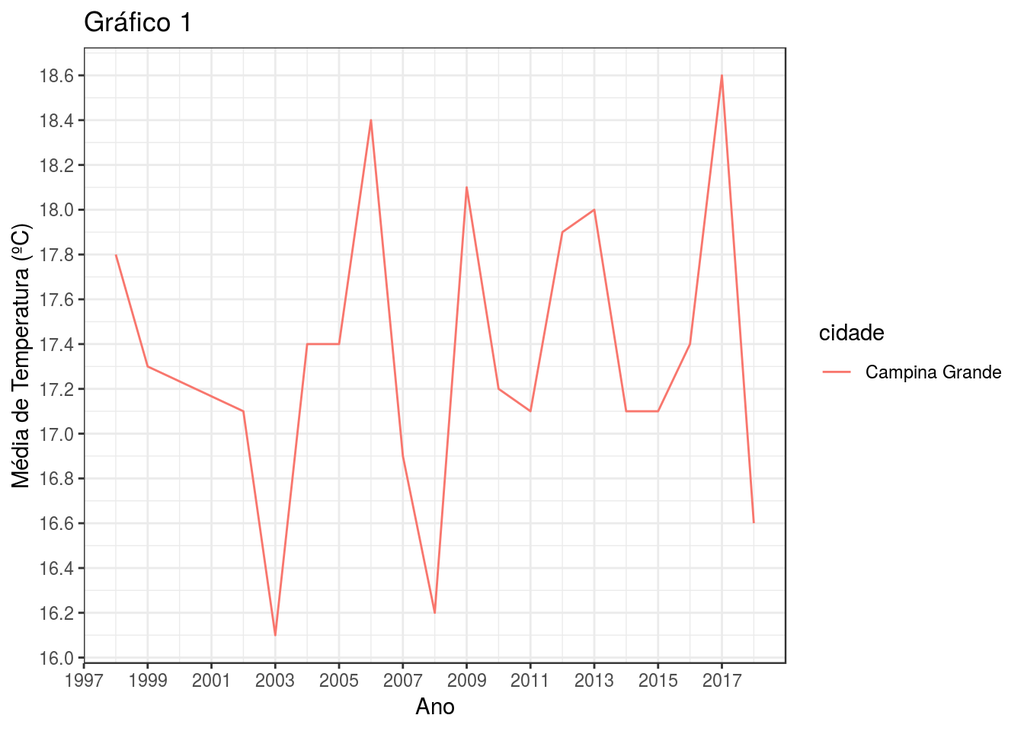

```r
climas %>%
    group_by(cidade, ano)  %>%
    filter(cidade %in% c("Campina Grande"), ano >= 1998, mes %in% c("6")) %>%
    summarise(temperatura = min(tmin)) %>%
    ggplot(mapping = aes(x = ano, y = temperatura, color = cidade)) +
    geom_line() +
    xlab("Ano") +
    ylab("Média de Temperatura (ºC)") +
    scale_x_continuous(breaks = seq(from = 1, to = 2018, by = 2)) +
    scale_y_continuous(breaks = seq(from = 1, to = 30, by = 0.2))  +
    ggtitle("Gráfico 1")
```

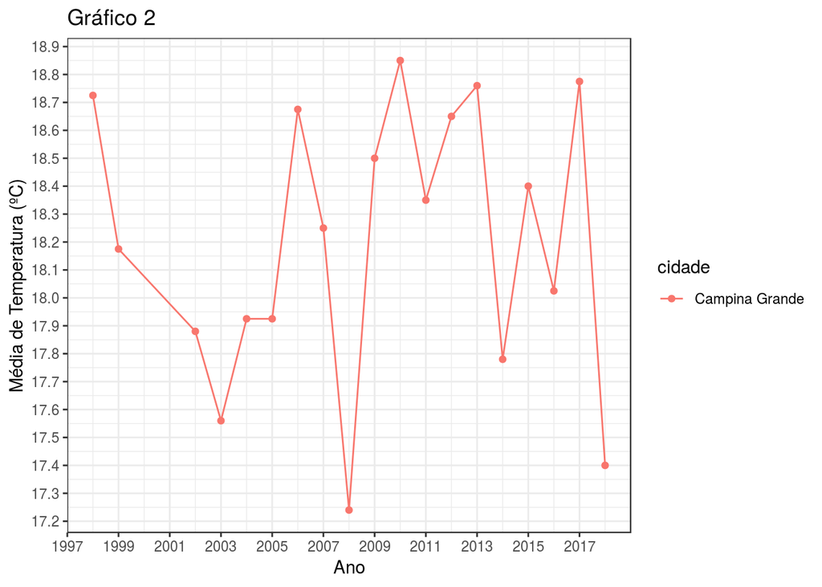

```r
climas %>%
    group_by(cidade, ano, mes)  %>%
    filter(!is.na(ano), mes %in% c("6"), cidade %in% c("Campina Grande"), ano >= 1998 , ano <= 2018) %>%
    summarise(temperatura = mean(tmin)) %>%
    ggplot(mapping = aes(x = ano, y = temperatura, color = cidade)) +
    geom_line() +
    geom_point() +
    xlab("Ano") +
    ylab("Média de Temperatura (ºC)") +
    scale_x_continuous(breaks = seq(from = 1, to = 2018, by = 2)) +
    scale_y_continuous(breaks = seq(from = 1, to = 30, by = 0.1))  +
    ggtitle("Gráfico 2")
```

## Onde é mais quente?

Para determinar qual o local mais quente, considerou-se que a média da média de temperatura desde o ano de 1998 a 2018 (20 anos). Dito isto, foi possível observar no gráfico 3 que a cidade de João Pessoa (aproximadamente 28ºC) possui a média de temperatura mais elevada que a cidade de Campina Grande (aproximadamente 25ºC).

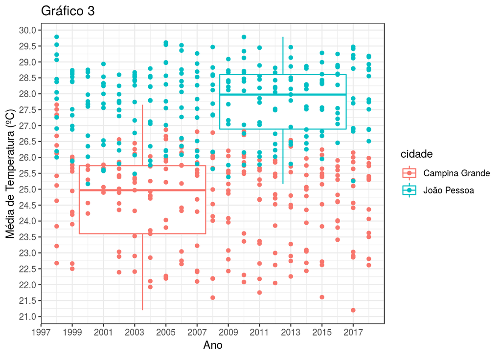

```r
climas %>%
    group_by(cidade, ano, mes)  %>%
    filter(ano >= 1998, ano <= 2018) %>%
    summarise(media_temperatura = mean(tmedia)) %>%
    ggplot(mapping = aes(x = ano, y = media_temperatura, color = cidade)) +
    geom_boxplot() +
    geom_point() +
    xlab("Ano") +
    ylab("Média de Temperatura (ºC)") +
    scale_x_continuous(breaks = seq(from = 1, to = 2018, by = 2))  +
    scale_y_continuous(breaks = seq(from = 1, to = 30, by = 0.5))  +
    ggtitle("Gráfico 3")
```

# Chuva

## No geral, onde chove mais?

Para determinar o local que acontece mais chuvas, considerou-se o a média de milímetros de chuva por cada cidade desde o ano de 1998 a 2018 (20 anos). Disto isto, é possível observar nos gráficos 4 e 5 que na cidade de João Pessoa (aproximadamente 35.4 ml) a média de chuvas é maior que a média de chuvas em Campina Grande (aproximadamente 13.3 ml).

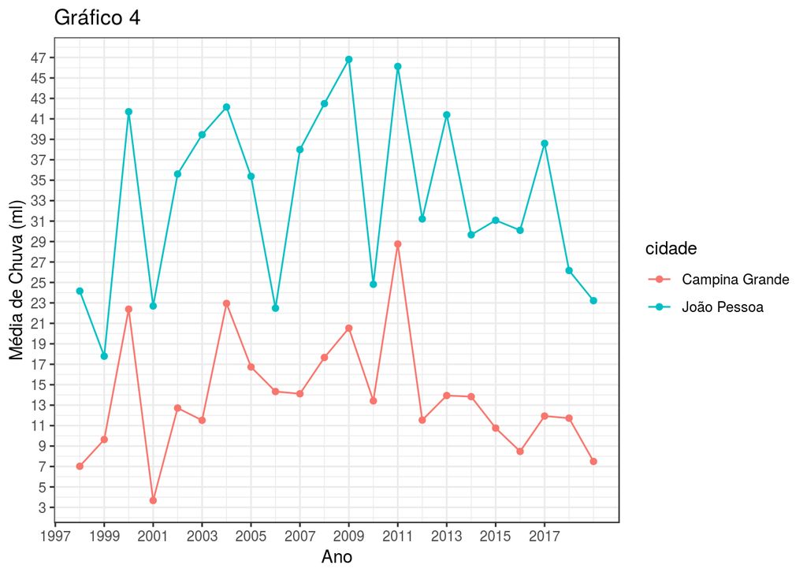

```r
climas %>%
    group_by(cidade, ano)  %>%
    filter(ano >= 1998) %>%
    summarise(media_chuva = mean(chuva)) %>%
    ggplot(mapping = aes(x = ano, y = media_chuva, color = cidade)) +
    geom_line() +
    geom_point() +
    #geom_smooth(aes(x = ano, y = media_chuva), method = lm, se = TRUE) +
    xlab("Ano") +
    ylab("Média de Chuva (ml)") +
    ggtitle("Gráfico 4") +
    scale_x_continuous(breaks = seq(from = 1, to = 2018, by = 2))  +
    scale_y_continuous(breaks = seq(from = 1, to = 300, by = 2))
```

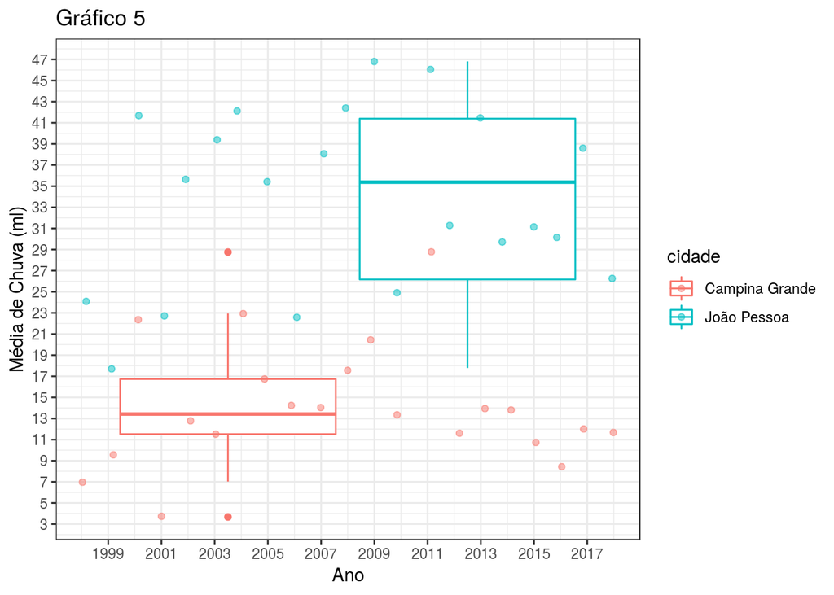

```r
climas %>%
    group_by(cidade, ano)  %>%
    filter(ano >= 1998, ano <= 2018) %>%
    summarise(media_chuva = mean(chuva)) %>%
    ggplot(mapping = aes(x = ano, y = media_chuva, color = cidade)) +
    geom_boxplot() +
    geom_jitter(width = .2, alpha = .5, height = 0.1) +
    xlab("Ano") +
    ylab("Média de Chuva (ml)") +
    scale_x_continuous(breaks = seq(from = 1, to = 2018, by = 2))  +
    scale_y_continuous(breaks = seq(from = 1, to = 300, by = 2))  +
    ggtitle("Gráfico 5")
```

# A distribuição é diferente em meses específicos?

```
Para determinar a variação mensal de milímetros de chuva, considerou-se o a média de milímetros de chuva por cidade em dois diferentes intervalos de anos:
De acordo com o gráfico 6, para o ano de 2018 a maior diferença concentra-se entre os meses de julho, março e abril respectivamente.
De acordo com o gráfico 7, já para uma distribuição entre os anos de 2008 a 2018 temos que a maior diferença de distribuição de milímetros de chuvas entre os meses são junho, maio e abril.
```

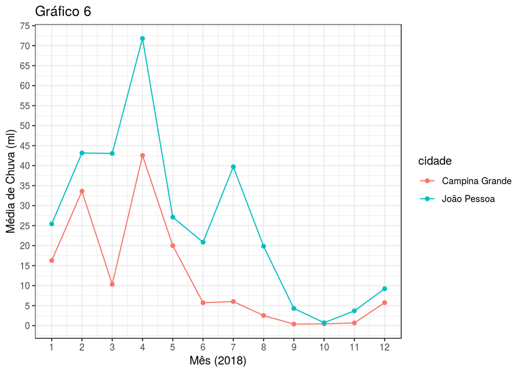

```r
climas %>%
    group_by(cidade, ano, mes)  %>%
    filter(ano == 2018) %>%
    summarise(media_chuva = mean(chuva)) %>%
    ggplot(mapping = aes(x = mes, y = media_chuva, color = cidade)) +
    geom_line() +
    geom_point() +
    #geom_smooth(aes(x = ano, y = media_chuva), method = lm, se = TRUE) +
    xlab("Mês (2018)") +
    ylab("Média de Chuva (ml)") +
    ggtitle("Gráfico 6") +
    scale_x_continuous(breaks = seq(from = 0, to = 2018, by = 1))  +
    scale_y_continuous(breaks = seq(from = 0, to = 300, by = 5))
```

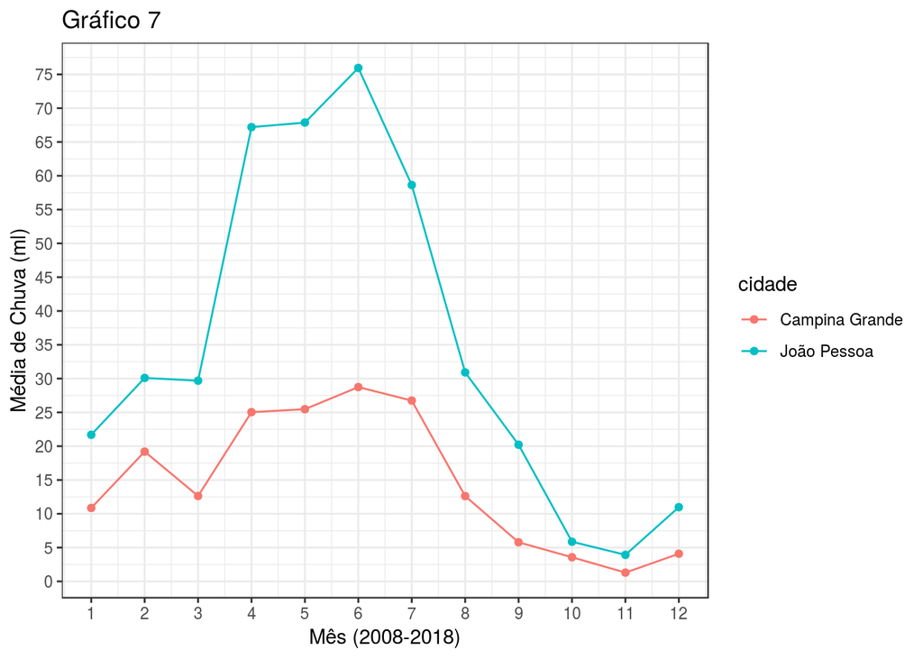

```r
climas %>%
    group_by(cidade, mes)  %>%
    filter(ano >= 2008) %>%
    summarise(media_chuva = mean(chuva)) %>%
    ggplot(mapping = aes(x = mes, y = media_chuva, color = cidade)) +
    geom_line() +
    geom_point() +
    #geom_smooth(aes(x = mes, y = media_chuva), method = lm, se = TRUE) +
    xlab("Mês (2008-2018)") +
    ylab("Média de Chuva (ml)") +
    ggtitle("Gráfico 7") +
    scale_x_continuous(breaks = seq(from = 0, to = 2018, by = 1))  +
    scale_y_continuous(breaks = seq(from = 0, to = 300, by = 5))
```